# A Hands-on Introduction to R - Female Code Lab

Κάθε αρχή και …. διάβασμα! όπως σε όλες(?) τις γλώσσες προγραμματισμού, ετσι και στην R, ξεκινάμε με το να εισαγουμε τις βιβλιοθήκες που θα χρησιμοποιήσουμε στο παρόν παράδειγμα. Τώρα θα μου πεις “και που να ξέρω κυρία μου τι θα χρησιμοποιήσω σαράντα γραμμές πιο κάτω?”. Ορθόν! εγώ συνήθως ακολουθώ ένα iterative process ή αλλιώς, όπως θα έλεγε η γιαγιά μου, “βλέποντας και κάνοντας”. Καθώς δηλαδή προχωρώ, αν ανακαλύψω ότι ξέχασα να εισάγω κάποια βιβλιοθήκη, τότε γυρίζω πίσω (εδώ, δηλαδή) και την συμπληρώνω.

```r
#Load the libraries that we will use

library(tidyverse)
library(here)
library(tidytext)
library(rtweet)
library(randomNames)
library(tidygraph)
library(ggraph)
library(igraph)
```

Μέρος Α: Ανάγνωση δεδομενων! δηλαδη? θα εισάγω τα δεδομένα από το αρχείο covid19_tweets.csv σε μία δομή δεδομένων της R. Αυτή τη δομή δεδομένων, θα την ονομάσω tweets.Από εδώ και στο εξής, θα μπορώ να ανασύρω ή να καλέσω τα δεδομένα μου χρησιμοποιώντας το όνομα tweets Η εντολή head μου δίνει μια γρήγορη επισκόπιση των δεδομένων που μολις διάβασα, ουσιαστικά τις έξι πρώτες γραμμές/εγγραφές που βρίσκονται τώρα στη δομή δεδομένων.

```r
#read the text data to use for today's example

tweets <- read.csv("./covid19_tweets.csv")
head(tweets)
```

|  | user_name | user_location | user_description | user_created | user_followers | user_friends | user_favourites | user_verified | date | text | hashtags | source | is_retweet |
| --- | --- | --- | --- | --- | --- | --- | --- | --- | --- | --- | --- | --- | --- |
| 1 | ᏉᎥ☻\u056cꂅ\u03ee | astroworld | wednesday addams as a disney princess keepin it [̲̅$̲̅(̲̅\u03b9\u03bf\u03bf̲̅)̲̅$̲̅] 👸🏻💚♊\ufe0f🧀🌵🌃🌙 | 2017-05-26 05:46:42 | 624 | 950 | 18775 | False | 2020-07-25 12:27:21 | If I smelled the scent of hand sanitizers today on someone in the past, I would think they were so intoxicated that… https://t.co/QZvYbrOgb0 |  | Twitter for iPhone | False |
| 2 | Tom Basile 🇺🇸 | New York, NY | Husband, Father, Columnist & Commentator. Author of Tough Sell: Fighting the Media War in Iraq. Bush Admin Alum. Newsmax Contributor. Fmr Exec Dir NYSGOP | 2009-04-16 20:06:23 | 2253 | 1677 | 24 | True | 2020-07-25 12:27:17 | Hey @Yankees @YankeesPR and @MLB - wouldn't it have made more sense to have the players pay their respects to the A… https://t.co/1QvW0zgyPu |  | Twitter for Android | False |
| 3 | Time4fisticuffs | Pewee Valley, KY | #Christian #Catholic #Conservative #Reagan #Republican #Capitalist; Sports lover - #BBN #Cincinnati #Reds #Bengals #Trump2020 | 2009-02-28 18:57:41 | 9275 | 9525 | 7254 | False | 2020-07-25 12:27:14 | @diane3443 @wdunlap @realDonaldTrump Trump never once claimed #COVID19 was a hoax. We all claim that this effort to… https://t.co/Jkk8vHWHb3 | ['COVID19'] | Twitter for Android | False |
| 4 | ethel mertz | Stuck in the Middle | #Browns #Indians #ClevelandProud #[]_[] #Cavs #Resist | 2019-03-07 01:45:06 | 197 | 987 | 1488 | False | 2020-07-25 12:27:10 | @brookbanktv The one gift #COVID19 has give me is an appreciation for the simple things that were always around me… https://t.co/Z0pOAlFXcW | ['COVID19'] | Twitter for iPhone | False |
| 5 | DIPR-J&K | Jammu and Kashmir | 🖊\ufe0fOfficial Twitter handle of Department of Information and Public Relations, Govt of Jammu & Kashmir | 2017-02-12 06:45:15 | 101009 | 168 | 101 | False | 2020-07-25 12:27:08 | 25 July : Media Bulletin on Novel #CoronaVirusUpdates #COVID19 \n@kansalrohit69 @DrSyedSehrish @airnewsalerts @ANI… https://t.co/MN0EEcsJHh | ['CoronaVirusUpdates', 'COVID19'] | Twitter for Android | False |
| 6 | 🎹 Franz Schubert | \u041d\u043e\u0432\u043e\u0440\u043é\u0441\u0441\u0438\u044f | 🎼 #\u041d\u043e\u0432\u043e\u0440\u043é\u0441\u0441\u0438\u044f #Novorossiya #\u043e\u0441\u0442\u0430\u0432\u0430\u0439\u0441\u044f\u0434\u043e\u043c\u0430 #STAYatHOME Polymath, composer, English. | 2018-03-19 16:29:52 | 1180 | 1071 | 1287 | False | 2020-07-25 12:27:06 | #coronavirus #covid19 deaths continue to rise. It's almost as bad as it ever was. Politicians and businesses want… https://t.co/hXMHooXX2C | ['coronavirus', 'covid19'] | Twitter Web App | False |

Λίγα λόγια για την επισκόπηση δεδομένων. Είτε μέσω κώδικα, είτε μέσω διεπιφάνειας χρήστη :) Όλοι οι παρακάτω τρόποι δίνουν το ίδιο αποτέλεσμα!

```r
tweets[1:4,'user_name']
```

```
[1] "ᏉᎥ☻\u056cꂅ\u03ee" "Tom Basile 🇺🇸"     "Time4fisticuffs"   "ethel mertz"
```

```r
tweets[1:4,1]
```

```
[1] "ᏉᎥ☻\u056cꂅ\u03ee" "Tom Basile 🇺🇸"     "Time4fisticuffs"   "ethel mertz"
```

```r
head(tweets$user_name,4)
```

```
[1] "ᏉᎥ☻\u056cꂅ\u03ee" "Tom Basile 🇺🇸"     "Time4fisticuffs"   "ethel mertz"
```

(Κάτι περίεργοι…) τύποι δεδομένων! Για να διαβάσω μία στήλη από τη δομή δεδομένων μου, αρκεί να την καλέσω με το όνομα της δομής, το χαρακτήρα $ και το ονομα της στήλης. Χρησιμοποιώντας την εντολή “names”μπορώ να δω τα ονόματα των στηλών στη δομή δεδομένων και με την εντολή glimpse μπορώ να δώ επιπρόσθετες πληροφορίες όπως ας πούμε τον τύπο δεδομένων (ακέραιοι, χαρακτήρες κλπ.)

```r
#take a closer look at the data and the data types
tweets$text <- as.character(tweets$text)


names(tweets)
```

```
 [1] "user_name"        "user_location"    "user_description" "user_created"     "user_followers"   "user_friends"     "user_favourites"
 [8] "user_verified"    "date"             "text"             "hashtags"         "source"           "is_retweet"
```

```r
glimpse(tweets)
```

```
Rows: 179,108
Columns: 13
$ user_name        <chr> "ᏉᎥ☻\u056cꂅ\u03ee", "Tom Basile 🇺🇸", "Time4fisticuffs", "ethel mertz", "DIPR-J&K", "🎹 Franz Schubert", "hr bart…
$ user_location    <chr> "astroworld", "New York, NY", "Pewee Valley, KY", "Stuck in the Middle ", "Jammu and Kashmir", "\u041d\u043e\u043…
$ user_description <chr> "wednesday addams as a disney princess keepin it [̲̅$̲̅(̲̅\u03b9\u03bf\u03bf̲̅)̲̅$̲̅] 👸🏻💚♊\ufe0f🧀🌵🌃🌙", "Husband, Fath…
$ user_created     <chr> "2017-05-26 05:46:42", "2009-04-16 20:06:23", "2009-02-28 18:57:41", "2019-03-07 01:45:06", "2017-02-12 06:45:15"…
$ user_followers   <int> 624, 2253, 9275, 197, 101009, 1180, 79956, 608, 25, 55201, 8, 241, 0, 830, 546, 274, 3987, 283, 46, 14, 292, 1066…
$ user_friends     <int> 950, 1677, 9525, 987, 168, 1071, 54810, 355, 29, 34239, 10, 1694, 8, 254, 29, 32, 53, 1432, 108, 24, 1037, 6, 183…
$ user_favourites  <int> 18775, 24, 7254, 1488, 101, 1287, 3801, 95, 18, 29802, 7, 8443, 32, 3692, 88, 378, 749, 1546, 453, 74, 58, 2037, …
$ user_verified    <chr> "False", "True", "False", "False", "False", "False", "False", "False", "False", "False", "False", "False", "False…
$ date             <chr> "2020-07-25 12:27:21", "2020-07-25 12:27:17", "2020-07-25 12:27:14", "2020-07-25 12:27:10", "2020-07-25 12:27:08"…
$ text             <chr> "If I smelled the scent of hand sanitizers today on someone in the past, I would think they were so intoxicated t…
$ hashtags         <chr> "", "", "['COVID19']", "['COVID19']", "['CoronaVirusUpdates', 'COVID19']", "['coronavirus', 'covid19']", "['COVID…
$ source           <chr> "Twitter for iPhone", "Twitter for Android", "Twitter for Android", "Twitter for iPhone", "Twitter for Android", …
$ is_retweet       <chr> "False", "False", "False", "False", "False", "False", "False", "False", "False", "False", "False", "False", "Fals…
```

##Interactions, interactions everywhere! (an intro to social network analysis)

Μέρος Β: και κολλάω εγώ τ’ αυτί τι είπε αυτός και τι είπε αυτή” [what](https://youtu.be/527gCV8WeWg)

Στο twitter, οταν κάποιος θέλει να απευθύνει τον λόγο σε κάποιον άλλο, χρησιμοποιεί το σύμβολο @ και το όνομα του χρήστη, πχ. @irene

ας απομονώσουμε αυτές τις περιπτώσεις:

```r
regex <- "@([A-Za-z]+[A-Za-z0-9_]+)(?![A-Za-z0-9_]*\\.)"

tweets <-
  tweets %>%
  # Use regular expression stored in regex to identify all the usernames in a tweet
  mutate(all_mentions = str_extract_all(text, regex)) %>%
  unnest(all_mentions)
```

```r
mentions <-
  tweets %>%
  mutate(all_mentions = str_trim(all_mentions)) %>%
  select(sender = user_name, all_mentions)
head(mentions)
```

| sender | all_mentions |
| --- | --- |
| Tom Basile 🇺🇸 | @Yankees |
| Tom Basile 🇺🇸 | @YankeesPR |
| Tom Basile 🇺🇸 | @MLB |
| Time4fisticuffs | @diane3443 |
| Time4fisticuffs | @wdunlap |
| Time4fisticuffs | @realDonaldTrump |

αλλα που ειναι οι σχέσεις?

```r
edgelist <-
  mentions %>%
  # remove "@" from all_mentions column
  mutate(all_mentions = str_sub(all_mentions, start = 2)) %>%
  # rename all_mentions to receiver
  select(sender, receiver = all_mentions)
head(edgelist)
```

| sender | receiver |
| --- | --- |
| Tom Basile 🇺🇸 | Yankees |
| Tom Basile 🇺🇸 | YankeesPR |
| Tom Basile 🇺🇸 | MLB |
| Time4fisticuffs | diane3443 |
| Time4fisticuffs | wdunlap |
| Time4fisticuffs | realDonaldTrump |

Μέρος Γ: οπτικοποίηση δεδομένων

```r
interactions_sent <- edgelist %>%

  count(sender) %>%
  arrange(desc(n))

head(interactions_sent)
```

| sender | n |
| --- | --- |
| APO Group English | 416 |
| Christine Carson | 335 |
| Malcolm Montgomery #WallOfVets | 332 |
| Dushyant Vachhani | 285 |
| COVID Scale | 191 |
| Pete Quily | 174 |

```r
nrow(interactions_sent)
```

```
[1] 31443
```

(Να το περιορίσουμε λίγο? Πχ. ας πούμε ότι ενδιαφερόμαστε για χρήστες που έκαναν παραπάνω από 1 mentions?)

```r
interactions_sent <-
  interactions_sent %>%
  #next line filters mentions based on count, e.g. filter out less than one
  filter(n > 1)

nrow(interactions_sent)
```

```
[1] 15050
```

και κρατάμε μόνο αυτούς τους χρήστες από το αρχικό σετ

```r
nrow(edgelist)
```

```
[1] 83877
```

```r
edgelist <- edgelist %>%
  filter(sender %in% interactions_sent$sender,
        receiver %in% interactions_sent$sender)
nrow(edgelist)
```

```
[1] 477
```

```r
#first column sender, second column receiver
g <-
  as_tbl_graph(edgelist)

g
```

```
# A tbl_graph: 451 nodes and 477 edges
#
# A directed multigraph with 97 components
#
# Node Data: 451 x 1 (active)
  name
  <chr>
1 Tom Basile 🇺🇸
2 Stella Infused Gammon Trigger
3 Gavin Drew #Russia_made_me_do_it
4 Nasdaq
5 KidsDroneZone
6 Gary Lennon
# … with 445 more rows
#
# Edge Data: 477 x 2
   from    to
  <int> <int>
1     1   388
2     2   389
3     3   390
# … with 474 more rows
```

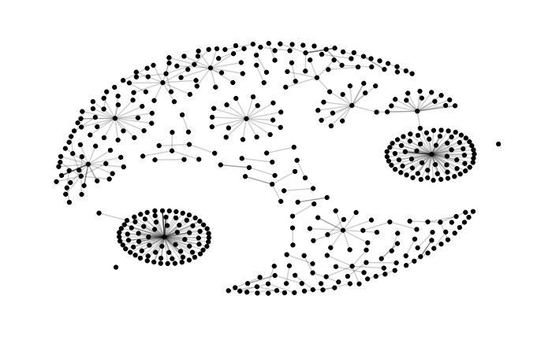

```r
#first column sender, second column receiver
g %>%
  # you can choose other layouts, maybe you want to try at home "drl"
  ggraph(layout = "kk") +
  # this adds the points to the graph
  geom_node_point() +
  # this adds the links, or the edges; alpha defines the weight of the line, that is a value of 0.8 will make it stronger
  geom_edge_link(alpha = .2) +

  #geom_node_text(aes(label = name), repel = TRUE, size = 10)  +
  theme_graph()
```

Ερώτηση: πως μπορούμε να δούμε ονόματα χρηστών στον γράφο? Η λύση ειναι απλή, όμως αν επιχειρήσω να εισάγω ονοματα στον παραπάνω γράφο, η επισκόπηση θα είναι μάλλον αδύνατη λόγω του σχετικά μεγάλου αριθμού κόμβων. Οπότε, θα επιχειρήσω να περιορίσω το μέγεθος του γράφου και μετά θα σχηματίσω το νέο, μικρότερο δίκτυο με τα ονόματα των χρηστών!

```r
interactions_sent_subset <-
  interactions_sent %>%
  #next line filters mentions based on count, e.g. filter out less than one
  filter(n >= 5)

edgelist_subset <- edgelist %>%
  filter(sender %in% interactions_sent_subset$sender,
        receiver %in% interactions_sent_subset$sender)

#first column sender, second column receiver
g_subset <-
  as_tbl_graph(edgelist_subset, weighted = TRUE)

g_subset
```

```
# A tbl_graph: 28 nodes and 43 edges
#
# A directed multigraph with 14 components
#
# Node Data: 28 x 1 (active)
  name
  <chr>
1 Nasdaq
2 Citizen / নাগরিক / Human Suman sengupta সুমন
3 PhocusWire
4 FISH_CGIAR
5 Neptune.
6 Pete Quily
# … with 22 more rows
#
# Edge Data: 43 x 2
   from    to
  <int> <int>
1     1     1
2     2    23
3     3     3
# … with 40 more rows
```

Όλα όπως πριν εκτός από μια γραμμή!

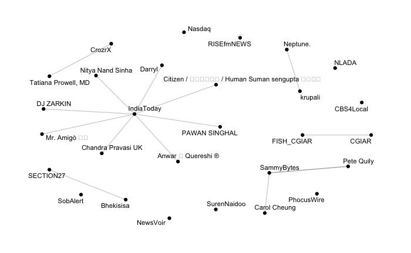

```r
g_subset %>%
  ggraph(layout = "kk") +
  geom_node_point() +

  geom_edge_link(alpha = .2) +
  #the following line prints out the name of each user (node) using font size 3
  geom_node_text(aes(label = name), repel = TRUE, size = 3)  +
  theme_graph()
```

Ερώτηση: μπορούμε να δούμε τη “δύναμη” της αλληλεπίδρασης μεταξύ δύο χρηστών? Ναι, φυσικά! ’Ομως πριν, ας ορίσουμε τι εννοούμε όταν λεμε “δύναμη”. Γενικά,όταν δουλεύουμε με κοινωνικά δίκτυα ορίζουμε την δύναμη ή το βάρος της αλληλεπίδρασης μεταξύ χρηστών συναρτήσει της συχνότητας επικοινωνίας τους ή του αριθμού μηνυμάτων που έχουν ανταλλάξει μεταξύ τους. Για το συγκεκριμένο παράδειγμα, ας πουμε ότι το βάρος ορίζεται ως ο αριθμός mentions ενός χρήστη προς έναν άλλο.

Σε πρώτη φάση, για τον απλοποιημένο γράφο του προηγούμενου παραδείγματος, θα μετρήσω πόσες φορές ένας χρήστης έκανε mention έναν άλλο και αυτόν τον αριθμό θα τον θέσω ως weight για να περιγράψω τη “δύναμη” της αλληλεπίδρασής τους. Για να το κάνω αυτό, ορίζω τη συνάρτηση edge.count που μου μετράει πόσες φορές επαναλαμβάνεται ένα ζεύγος “sender-receiver” και αποθηκεύω τα αποτελέσματα στη δομή δεδομένων weighted.edges

```r
edge.count <- function(g){
     result <- cbind(E(g), count.multiple(g))
     colnames(result) <- c("edge", "count")
     result
}

weighted.edges <- as.data.frame(edge.count(g_subset))
#weighted.edges["percent"] <- weighted.edges$count / sum(weighted.edges$count)
```

Στη συνέχεια, προσθέτω τη νέα πληροφορία για τα βάρη (weights) στον γράφο που ήδη έχω κατασκευάσει

```r
g_weighted_subset <- g_subset %>% activate(edges) %>% mutate(weight = weighted.edges$count)
g_weighted_subset
```

```
# A tbl_graph: 28 nodes and 43 edges
#
# A directed multigraph with 14 components
#
# Edge Data: 43 x 3 (active)
   from    to weight
  <int> <int>  <dbl>
1     1     1      3
2     2    23      1
3     3     3     15
4     4    24      1
5     3     3     15
6     3     3     15
# … with 37 more rows
#
# Node Data: 28 x 1
  name
  <chr>
1 Nasdaq
2 Citizen / নাগরিক / Human Suman sengupta সুমন
3 PhocusWire
# … with 25 more rows
```

Και τελευταίο βήμα, τυπώνω ξανά τον γράφο!

[figure not shown]

```r
g_weighted_subset %>%
  ggraph(layout = "kk") +
  geom_edge_link(aes(edge_width = weight)) +
  geom_node_point() +

  geom_edge_link(alpha = .2) +
  #the following line prints out the name of each user (node) using font size 3
  geom_node_text(aes(label = name), repel = TRUE, size = 3)  +
  theme_graph()
```

Μέρος Δ: Ναι, το κατάλαβα και θέλω ν’ακούσω κι άλλα!